# Branch Length Summary Stats Analysis

## Goal

The primary goal of this analysis is to determine whether branch length summary statistics differ across protein models.

## First let’s read in the datasets, create smaller versions of them to work with, and then create a tibble with several branch length summary statistics.

## The summarized branch lengths:

```r
print(summarized_bl)
```

```
## # A tibble: 216,390 x 11
##    model ASRV  id    dataset treelength mean_bl median_bl   sd_bl cov_bl  min_bl
##    <chr> <lgl> <chr> <chr>        <dbl>   <dbl>     <dbl>   <dbl>  <dbl>   <dbl>
##  1 FLU   FALSE 100   birds        2.60  0.0456    0.0300  0.0615   1.35  2.00e-6
##  2 FLU   FALSE 1000  birds        0.755 0.00981   0.00727 0.00984  1.00  2.02e-6
##  3 FLU   FALSE 10003 birds        3.48  0.0611    0.0289  0.104    1.70  2.23e-6
##  4 FLU   FALSE 10004 birds        1.86  0.0249    0.0136  0.0304   1.22  2.06e-6
##  5 FLU   FALSE 10005 birds        0.278 0.00428   0.00430 0.00600  1.40  0
##  6 FLU   FALSE 10009 birds        0.557 0.00784   0.00763 0.00771  0.984 2.06e-6
##  7 FLU   FALSE 10012 birds        0.965 0.0140    0.00496 0.0224   1.60  1   e-6
##  8 FLU   FALSE 10013 birds        1.02  0.0135    0.00742 0.0135   1.00  2.07e-6
##  9 FLU   FALSE 10017 birds        1.76  0.0374    0.0296  0.0331   0.884 2.18e-6
## 10 FLU   FALSE 1002  birds        3.01  0.0568    0.0381  0.0616   1.09  2.31e-6
## # … with 216,380 more rows, and 1 more variable: max_bl <dbl>
```

This dataset contains branch length summary statistics (columns) for a number of selected id’s from the bird, mammal, and enzyme datasets. Moving forward, we will use this dataset to determine if these summary statistics differ across protein models (JTT, WAG, FLU, Poisson, and LG).

## Analysis of Branchlength Differences Between Models

Okay, now that we have our mini-dataset, let’s begin to see how the branch length summary stats look! We will begin with some violin plots of treelength, max branch length, and mean branch length. Analysis of the results comes after the three plots.

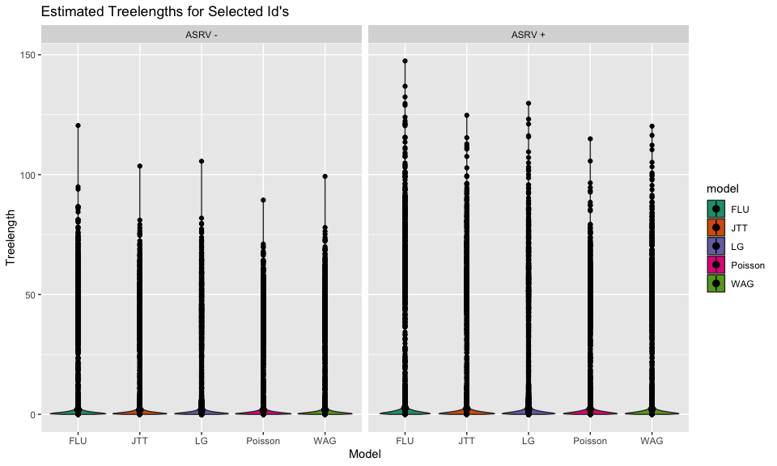

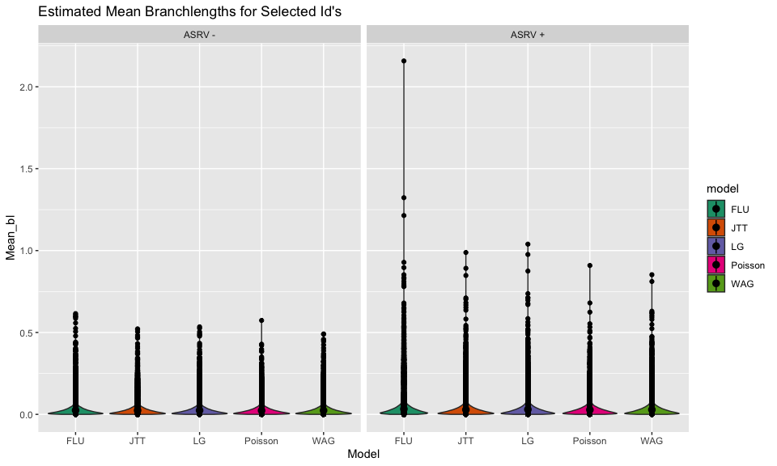

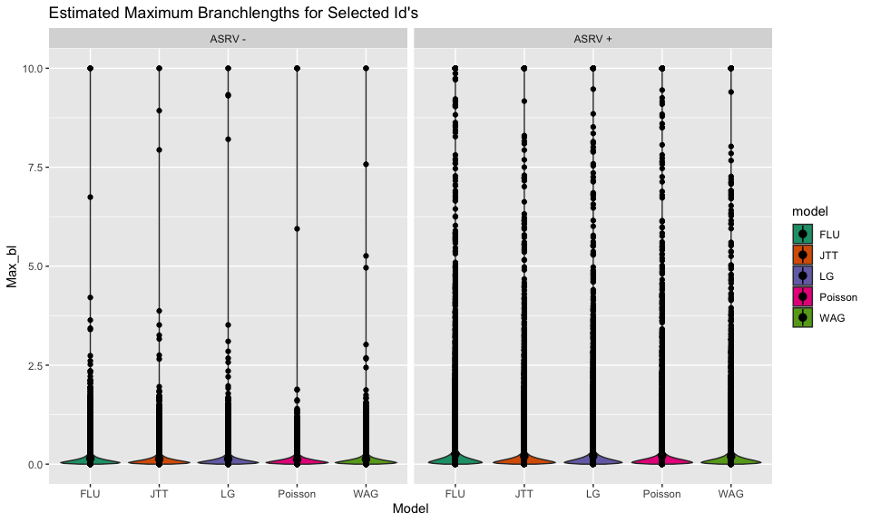

-From this, we first see that FLU *appears* to overestimate the branch length related measurements while Poisson underestimates.

-`enzymes` summary statistics are elevated compared to those of `birds` or `mammals`. Therefore, the points grouped towards the top of each violin are estimates from the `enzymes` dataset.

-It is expected that `ASRV+` plots display more evolutionary change since sites are likely to mutate at different rates due do differing evolutionary pressures.

-Overall, this analysis suggests that it may be interesting to run the summary statistics without the enzyme data, to see how the models perform under lower-variance conditions. Maybe the overestimation by FLU and the underestimation by Poisson are due to the high variation alone, in which case we could approximate *how much* variance these models can “handle” before they are no longer reliable.

### Now, Let’s continue to address our goal, but this time by utilizing linear models to determine if branch length *summary statistics* do indeed differ across protein models. Specifically, we will look at mean branch length, treelength, and max branch length.

-For our analysis, we will conduct (9) linear models for *each* summary statistic of interest (`mean_bl`, `treelength`, and `max_bl`). There will be only one “type one” linear model for each summary statistic since the this type of model relies on there being variation in the `dataset` variable, which is only found in the `summarized bl` dataset. There will then be four (4) type 2 and four (4) type three linear models carried out for *each* statistic (one each from `birds_bl`, `mammals_bl`, `enzymes_bl`, and `summarized_bl`). Overall, this leaves us with one type 1 model, four type 2 models, and four type 3 models for each summary stat of interest. Since we are concerned with three summary stats total, this leaves us with 27 linear models to analyze!

# Model Types

- **Type 1**: `summary stat ~ protein model + dataset + presence of ASRV`
  - birds, mammals, and enzymes are regarded as separate datasets
- **Type 2**: `summary stat ~ protein model + presence of ASRV`
  - birds, mammals, enzymes are regarded as a single dataset
- **Type 3**: `summary stat ~ protein model`
  - birds, mammals, enzymes are regarded as a single dataset

First, we will look at mean branch length as our branch length summary statistic of interest. A detailed analysis of the model outputs can be found after all plots and charts are shown.

## Mean Branch Length

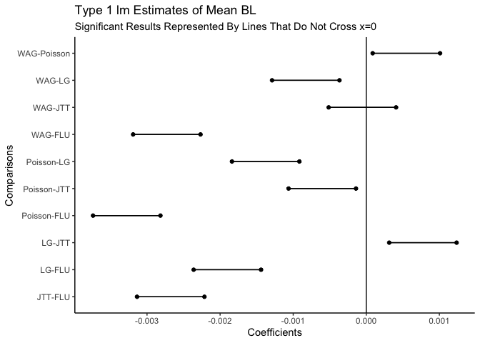

Type 1 lm Estimates of Mean BL

Significant P values highlighted in red

| comparison | diff | lwr | upr | p adj |
| --- | --- | --- | --- | --- |
| JTT-FLU | -2.675559e-03 | -3.136644e-03 | -0.0022144734 | 0.000 |
| LG-FLU | -1.900847e-03 | -2.361932e-03 | -0.0014397612 | 0.000 |
| Poisson-FLU | -3.277571e-03 | -3.738657e-03 | -0.0028164858 | 0.000 |
| WAG-FLU | -2.728991e-03 | -3.190076e-03 | -0.0022679052 | 0.000 |
| LG-JTT | 7.747122e-04 | 3.136268e-04 | 0.0012357976 | 0.000 |
| Poisson-JTT | -6.020125e-04 | -1.063098e-03 | -0.0001409271 | 0.003 |
| WAG-JTT | -5.343187e-05 | -5.145173e-04 | 0.0004076535 | 0.998 |
| Poisson-LG | -1.376725e-03 | -1.837810e-03 | -0.0009156393 | 0.000 |
| WAG-LG | -8.281440e-04 | -1.289229e-03 | -0.0003670587 | 0.000 |
| WAG-Poisson | 5.485806e-04 | 8.749521e-05 | 0.0010096660 | 0.010 |

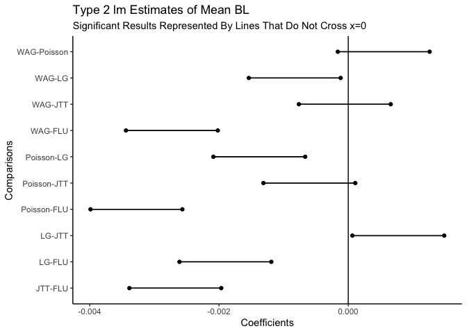

Type 2 lm Estimates of Mean BL

Significant P values highlighted in red

| comparison | diff | lwr | upr | p adj |
| --- | --- | --- | --- | --- |
| JTT-FLU | -2.675559e-03 | -3.386082e-03 | -0.0019650353 | 0.000 |
| LG-FLU | -1.900847e-03 | -2.611370e-03 | -0.0011903231 | 0.000 |
| Poisson-FLU | -3.277571e-03 | -3.988095e-03 | -0.0025670478 | 0.000 |
| WAG-FLU | -2.728991e-03 | -3.439514e-03 | -0.0020184672 | 0.000 |
| LG-JTT | 7.747122e-04 | 6.418873e-05 | 0.0014852356 | 0.025 |
| Poisson-JTT | -6.020125e-04 | -1.312536e-03 | 0.0001085110 | 0.141 |
| WAG-JTT | -5.343187e-05 | -7.639553e-04 | 0.0006570916 | 1.000 |
| Poisson-LG | -1.376725e-03 | -2.087248e-03 | -0.0006662012 | 0.000 |
| WAG-LG | -8.281440e-04 | -1.538667e-03 | -0.0001176206 | 0.013 |
| WAG-Poisson | 5.485806e-04 | -1.619429e-04 | 0.0012591040 | 0.217 |

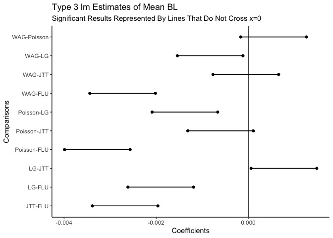

Type 3 lm Estimates of Mean BL

Significant P values highlighted in red

| comparison | diff | lwr | upr | p adj |
| --- | --- | --- | --- | --- |
| JTT-FLU | -2.675559e-03 | -3.387986e-03 | -0.0019631312 | 0.000 |
| LG-FLU | -1.900847e-03 | -2.613274e-03 | -0.0011884191 | 0.000 |
| Poisson-FLU | -3.277571e-03 | -3.989999e-03 | -0.0025651437 | 0.000 |
| WAG-FLU | -2.728991e-03 | -3.441418e-03 | -0.0020165631 | 0.000 |
| LG-JTT | 7.747122e-04 | 6.228466e-05 | 0.0014871397 | 0.025 |
| Poisson-JTT | -6.020125e-04 | -1.314440e-03 | 0.0001104151 | 0.143 |
| WAG-JTT | -5.343187e-05 | -7.658594e-04 | 0.0006589957 | 1.000 |
| Poisson-LG | -1.376725e-03 | -2.089152e-03 | -0.0006642971 | 0.000 |
| WAG-LG | -8.281440e-04 | -1.540572e-03 | -0.0001157165 | 0.013 |
| WAG-Poisson | 5.485806e-04 | -1.638469e-04 | 0.0012610081 | 0.220 |

### Birds_bl mean_bl

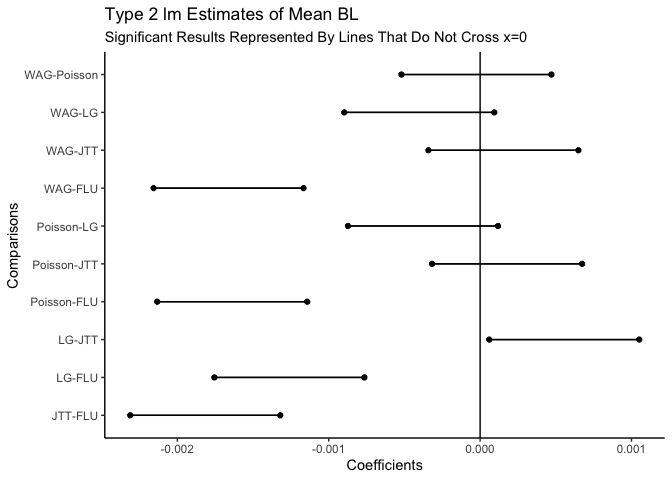

Type 2 lm Estimates of Mean BL

Significant P values highlighted in red

| comparison | diff | lwr | upr | p adj |
| --- | --- | --- | --- | --- |
| JTT-FLU | -0.0018158698 | -2.311376e-03 | -1.320364e-03 | 0.000 |
| LG-FLU | -0.0012600858 | -1.755592e-03 | -7.645796e-04 | 0.000 |
| Poisson-FLU | -0.0016375770 | -2.133083e-03 | -1.142071e-03 | 0.000 |
| WAG-FLU | -0.0016620017 | -2.157508e-03 | -1.166495e-03 | 0.000 |
| LG-JTT | 0.0005557840 | 6.027783e-05 | 1.051290e-03 | 0.019 |
| Poisson-JTT | 0.0001782928 | -3.172133e-04 | 6.737990e-04 | 0.864 |
| WAG-JTT | 0.0001538681 | -3.416380e-04 | 6.493743e-04 | 0.916 |
| Poisson-LG | -0.0003774912 | -8.729973e-04 | 1.180150e-04 | 0.230 |
| WAG-LG | -0.0004019159 | -8.974220e-04 | 9.359031e-05 | 0.175 |
| WAG-Poisson | -0.0000244247 | -5.199309e-04 | 4.710815e-04 | 1.000 |

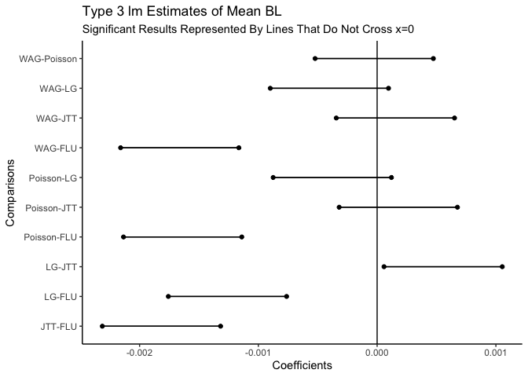

Type 3 lm Estimates of Mean BL

Significant P values highlighted in red

| comparison | diff | lwr | upr | p adj |
| --- | --- | --- | --- | --- |
| JTT-FLU | -0.0018158698 | -2.313698e-03 | -1.318042e-03 | 0.000 |
| LG-FLU | -0.0012600858 | -1.757914e-03 | -7.622579e-04 | 0.000 |
| Poisson-FLU | -0.0016375770 | -2.135405e-03 | -1.139749e-03 | 0.000 |
| WAG-FLU | -0.0016620017 | -2.159830e-03 | -1.164174e-03 | 0.000 |
| LG-JTT | 0.0005557840 | 5.795608e-05 | 1.053612e-03 | 0.020 |
| Poisson-JTT | 0.0001782928 | -3.195351e-04 | 6.761208e-04 | 0.866 |
| WAG-JTT | 0.0001538681 | -3.439598e-04 | 6.516961e-04 | 0.917 |
| Poisson-LG | -0.0003774912 | -8.753191e-04 | 1.203368e-04 | 0.234 |
| WAG-LG | -0.0004019159 | -8.997438e-04 | 9.591206e-05 | 0.179 |
| WAG-Poisson | -0.0000244247 | -5.222526e-04 | 4.734032e-04 | 1.000 |

### Mammals_bl mean_bl

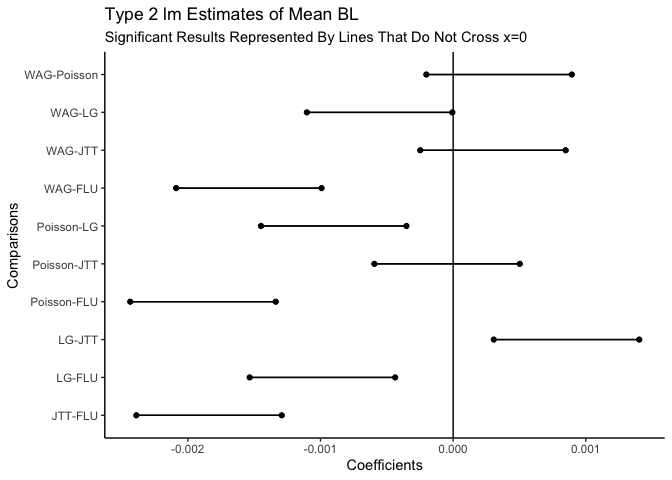

Type 2 lm Estimates of Mean BL

Significant P values highlighted in red

| comparison | diff | lwr | upr | p adj |
| --- | --- | --- | --- | --- |
| JTT-FLU | -1.840204e-03 | -0.0023884926 | -1.291916e-03 | 0.000 |
| LG-FLU | -9.856125e-04 | -0.0015339007 | -4.373243e-04 | 0.000 |
| Poisson-FLU | -1.886071e-03 | -0.0024343592 | -1.337783e-03 | 0.000 |
| WAG-FLU | -1.540065e-03 | -0.0020883536 | -9.917772e-04 | 0.000 |
| LG-JTT | 8.545919e-04 | 0.0003063037 | 1.402880e-03 | 0.000 |
| Poisson-JTT | -4.586654e-05 | -0.0005941547 | 5.024217e-04 | 0.999 |
| WAG-JTT | 3.001390e-04 | -0.0002481492 | 8.484272e-04 | 0.567 |
| Poisson-LG | -9.004585e-04 | -0.0014487467 | -3.521703e-04 | 0.000 |
| WAG-LG | -5.544529e-04 | -0.0011027411 | -6.164719e-06 | 0.046 |
| WAG-Poisson | 3.460056e-04 | -0.0002022826 | 8.942937e-04 | 0.421 |

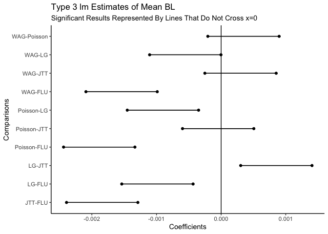

Type 3 lm Estimates of Mean BL

Significant P values highlighted in red

| comparison | diff | lwr | upr | p adj |
| --- | --- | --- | --- | --- |
| JTT-FLU | -1.840204e-03 | -0.0023920223 | -1.288387e-03 | 0.000 |
| LG-FLU | -9.856125e-04 | -0.0015374304 | -4.337946e-04 | 0.000 |
| Poisson-FLU | -1.886071e-03 | -0.0024378888 | -1.334253e-03 | 0.000 |
| WAG-FLU | -1.540065e-03 | -0.0020918833 | -9.882476e-04 | 0.000 |
| LG-JTT | 8.545919e-04 | 0.0003027741 | 1.406410e-03 | 0.000 |
| Poisson-JTT | -4.586654e-05 | -0.0005976844 | 5.059513e-04 | 0.999 |
| WAG-JTT | 3.001390e-04 | -0.0002516788 | 8.519569e-04 | 0.573 |
| Poisson-LG | -9.004585e-04 | -0.0014522763 | -3.486406e-04 | 0.000 |
| WAG-LG | -5.544529e-04 | -0.0011062708 | -2.635044e-06 | 0.048 |
| WAG-Poisson | 3.460056e-04 | -0.0002058123 | 8.978234e-04 | 0.427 |

### Enzymes_bl mean_bl

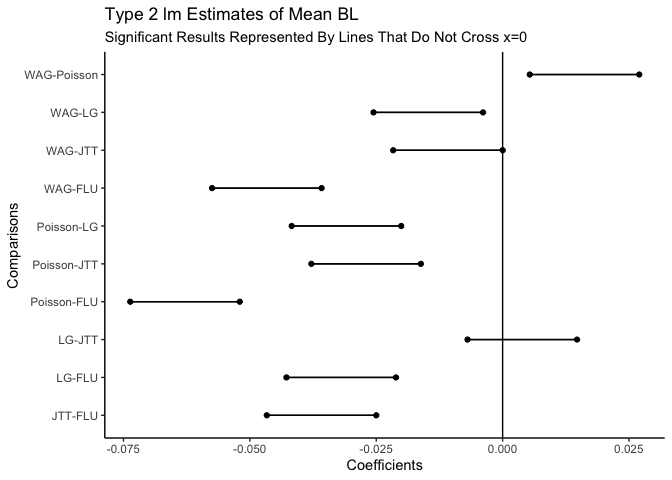

Type 2 lm Estimates of Mean BL

Significant P values highlighted in red

| comparison | diff | lwr | upr | p adj |
| --- | --- | --- | --- | --- |
| JTT-FLU | -0.035822401 | -0.046654487 | -2.499032e-02 | 0.000 |
| LG-FLU | -0.031934750 | -0.042766836 | -2.110266e-02 | 0.000 |
| Poisson-FLU | -0.062830900 | -0.073662986 | -5.199881e-02 | 0.000 |
| WAG-FLU | -0.046638989 | -0.057471076 | -3.580690e-02 | 0.000 |
| LG-JTT | 0.003887651 | -0.006944435 | 1.471974e-02 | 0.865 |
| Poisson-JTT | -0.027008498 | -0.037840584 | -1.617641e-02 | 0.000 |
| WAG-JTT | -0.010816588 | -0.021648674 | 1.549791e-05 | 0.051 |
| Poisson-LG | -0.030896150 | -0.041728236 | -2.006406e-02 | 0.000 |
| WAG-LG | -0.014704240 | -0.025536326 | -3.872153e-03 | 0.002 |
| WAG-Poisson | 0.016191910 | 0.005359824 | 2.702400e-02 | 0.000 |

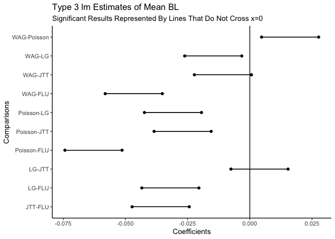

Type 3 lm Estimates of Mean BL

Significant P values highlighted in red

| comparison | diff | lwr | upr | p adj |
| --- | --- | --- | --- | --- |
| JTT-FLU | -0.035822401 | -0.047297523 | -0.0243472792 | 0.000 |
| LG-FLU | -0.031934750 | -0.043409872 | -0.0204596278 | 0.000 |
| Poisson-FLU | -0.062830900 | -0.074306022 | -0.0513557776 | 0.000 |
| WAG-FLU | -0.046638989 | -0.058114112 | -0.0351638674 | 0.000 |
| LG-JTT | 0.003887651 | -0.007587471 | 0.0153627735 | 0.888 |
| Poisson-JTT | -0.027008498 | -0.038483620 | -0.0155333763 | 0.000 |
| WAG-JTT | -0.010816588 | -0.022291710 | 0.0006585339 | 0.076 |
| Poisson-LG | -0.030896150 | -0.042371272 | -0.0194210277 | 0.000 |
| WAG-LG | -0.014704240 | -0.026179362 | -0.0032291175 | 0.004 |
| WAG-Poisson | 0.016191910 | 0.004716788 | 0.0276670323 | 0.001 |

## Treelength

Next, we will look at treelength as our branch length summary statistic of interest.

### Summarized_bl Treelength

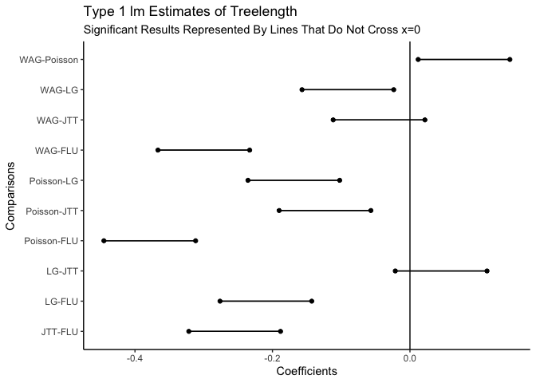

Type 1 lm Estimates of Treelength

Significant P values highlighted in red

| comparison | diff | lwr | upr | p adj |
| --- | --- | --- | --- | --- |
| JTT-FLU | -0.25495054 | -0.32166063 | -0.18824044 | 0.000 |
| LG-FLU | -0.20958227 | -0.27629236 | -0.14287217 | 0.000 |
| Poisson-FLU | -0.37851349 | -0.44522359 | -0.31180340 | 0.000 |
| WAG-FLU | -0.29988175 | -0.36659184 | -0.23317165 | 0.000 |
| LG-JTT | 0.04536827 | -0.02134183 | 0.11207836 | 0.342 |
| Poisson-JTT | -0.12356296 | -0.19027305 | -0.05685286 | 0.000 |
| WAG-JTT | -0.04493121 | -0.11164130 | 0.02177888 | 0.352 |
| Poisson-LG | -0.16893123 | -0.23564132 | -0.10222113 | 0.000 |
| WAG-LG | -0.09029948 | -0.15700957 | -0.02358939 | 0.002 |
| WAG-Poisson | 0.07863175 | 0.01192165 | 0.14534184 | 0.011 |

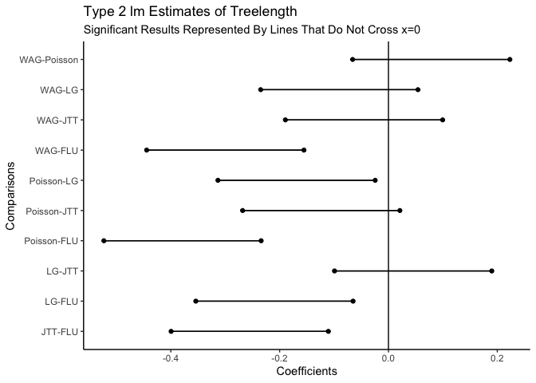

Type 2 lm Estimates of Treelength

Significant P values highlighted in red

| comparison | diff | lwr | upr | p adj |
| --- | --- | --- | --- | --- |
| JTT-FLU | -0.25495054 | -0.39946469 | -0.11043639 | 0.000 |
| LG-FLU | -0.20958227 | -0.35409642 | -0.06506812 | 0.001 |
| Poisson-FLU | -0.37851349 | -0.52302764 | -0.23399934 | 0.000 |
| WAG-FLU | -0.29988175 | -0.44439590 | -0.15536760 | 0.000 |
| LG-JTT | 0.04536827 | -0.09914588 | 0.18988242 | 0.913 |
| Poisson-JTT | -0.12356296 | -0.26807711 | 0.02095119 | 0.135 |
| WAG-JTT | -0.04493121 | -0.18944536 | 0.09958294 | 0.915 |
| Poisson-LG | -0.16893123 | -0.31344538 | -0.02441708 | 0.012 |
| WAG-LG | -0.09029948 | -0.23481363 | 0.05421467 | 0.431 |
| WAG-Poisson | 0.07863175 | -0.06588240 | 0.22314590 | 0.573 |

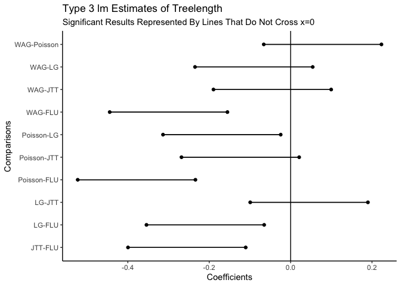

Type 3 lm Estimates of Treelength

Significant P values highlighted in red

| comparison | diff | lwr | upr | p adj |
| --- | --- | --- | --- | --- |
| JTT-FLU | -0.25495054 | -0.39954280 | -0.11035828 | 0.000 |
| LG-FLU | -0.20958227 | -0.35417453 | -0.06499001 | 0.001 |
| Poisson-FLU | -0.37851349 | -0.52310575 | -0.23392123 | 0.000 |
| WAG-FLU | -0.29988175 | -0.44447401 | -0.15528949 | 0.000 |
| LG-JTT | 0.04536827 | -0.09922399 | 0.18996053 | 0.913 |
| Poisson-JTT | -0.12356296 | -0.26815522 | 0.02102930 | 0.135 |
| WAG-JTT | -0.04493121 | -0.18952347 | 0.09966105 | 0.916 |
| Poisson-LG | -0.16893123 | -0.31352349 | -0.02433897 | 0.013 |
| WAG-LG | -0.09029948 | -0.23489174 | 0.05429278 | 0.432 |
| WAG-Poisson | 0.07863175 | -0.06596051 | 0.22322401 | 0.573 |

### Birds_bl Treelength

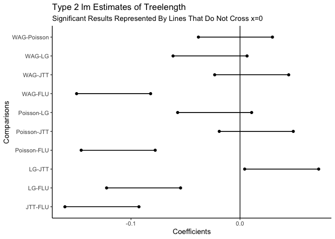

Type 2 lm Estimates of Treelength

Significant P values highlighted in red

| comparison | diff | lwr | upr | p adj |
| --- | --- | --- | --- | --- |
| JTT-FLU | -0.126616983 | -0.160548491 | -0.092685474 | 0.000 |
| LG-FLU | -0.088430811 | -0.122362319 | -0.054499303 | 0.000 |
| Poisson-FLU | -0.111708049 | -0.145639557 | -0.077776541 | 0.000 |
| WAG-FLU | -0.115916330 | -0.149847838 | -0.081984822 | 0.000 |
| LG-JTT | 0.038186172 | 0.004254664 | 0.072117680 | 0.018 |
| Poisson-JTT | 0.014908934 | -0.019022574 | 0.048840442 | 0.752 |
| WAG-JTT | 0.010700653 | -0.023230856 | 0.044632161 | 0.911 |
| Poisson-LG | -0.023277238 | -0.057208746 | 0.010654270 | 0.333 |
| WAG-LG | -0.027485519 | -0.061417028 | 0.006445989 | 0.176 |
| WAG-Poisson | -0.004208281 | -0.038139790 | 0.029723227 | 0.997 |

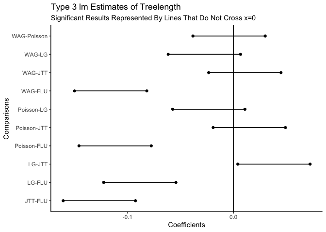

Type 3 lm Estimates of Treelength

Significant P values highlighted in red

| comparison | diff | lwr | upr | p adj |
| --- | --- | --- | --- | --- |
| JTT-FLU | -0.126616983 | -0.160719701 | -0.092514264 | 0.000 |
| LG-FLU | -0.088430811 | -0.122533529 | -0.054328092 | 0.000 |
| Poisson-FLU | -0.111708049 | -0.145810767 | -0.077605331 | 0.000 |
| WAG-FLU | -0.115916330 | -0.150019049 | -0.081813612 | 0.000 |
| LG-JTT | 0.038186172 | 0.004083453 | 0.072288890 | 0.019 |
| Poisson-JTT | 0.014908934 | -0.019193785 | 0.049011652 | 0.756 |
| WAG-JTT | 0.010700653 | -0.023402066 | 0.044803371 | 0.913 |
| Poisson-LG | -0.023277238 | -0.057379956 | 0.010825480 | 0.338 |
| WAG-LG | -0.027485519 | -0.061588238 | 0.006617199 | 0.180 |
| WAG-Poisson | -0.004208281 | -0.038311000 | 0.029894437 | 0.997 |

### Mammals_bl Treelength

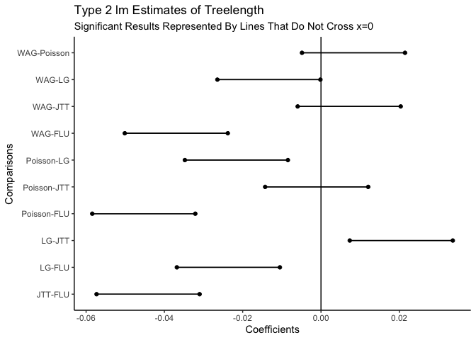

Type 2 lm Estimates of Treelength

Significant P values highlighted in red

| comparison | diff | lwr | upr | p adj |
| --- | --- | --- | --- | --- |
| JTT-FLU | -0.044164907 | -0.057323823 | -0.0310059900 | 0.000 |
| LG-FLU | -0.023654700 | -0.036813617 | -0.0104957836 | 0.000 |
| Poisson-FLU | -0.045265703 | -0.058424620 | -0.0321067868 | 0.000 |
| WAG-FLU | -0.036961570 | -0.050120487 | -0.0238026535 | 0.000 |
| LG-JTT | 0.020510206 | 0.007351290 | 0.0336691230 | 0.000 |
| Poisson-JTT | -0.001100797 | -0.014259713 | 0.0120581197 | 0.999 |
| WAG-JTT | 0.007203336 | -0.005955580 | 0.0203622531 | 0.567 |
| Poisson-LG | -0.021611003 | -0.034769920 | -0.0084520866 | 0.000 |
| WAG-LG | -0.013306870 | -0.026465786 | -0.0001479533 | 0.046 |
| WAG-Poisson | 0.008304133 | -0.004854783 | 0.0214630500 | 0.421 |

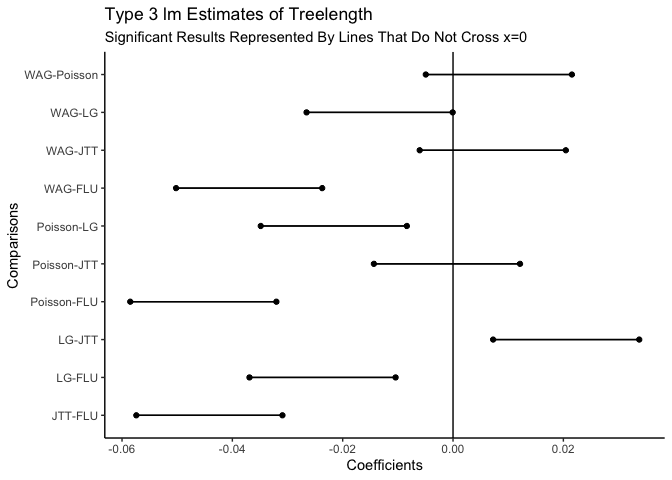

Type 3 lm Estimates of Treelength

Significant P values highlighted in red

| comparison | diff | lwr | upr | p adj |
| --- | --- | --- | --- | --- |
| JTT-FLU | -0.044164907 | -0.057408535 | -3.092128e-02 | 0.000 |
| LG-FLU | -0.023654700 | -0.036898329 | -1.041107e-02 | 0.000 |
| Poisson-FLU | -0.045265703 | -0.058509332 | -3.202207e-02 | 0.000 |
| WAG-FLU | -0.036961570 | -0.050205199 | -2.371794e-02 | 0.000 |
| LG-JTT | 0.020510206 | 0.007266578 | 3.375384e-02 | 0.000 |
| Poisson-JTT | -0.001100797 | -0.014344426 | 1.214283e-02 | 0.999 |
| WAG-JTT | 0.007203336 | -0.006040292 | 2.044697e-02 | 0.573 |
| Poisson-LG | -0.021611003 | -0.034854632 | -8.367374e-03 | 0.000 |
| WAG-LG | -0.013306870 | -0.026550499 | -6.324107e-05 | 0.048 |
| WAG-Poisson | 0.008304133 | -0.004939495 | 2.154776e-02 | 0.427 |

### Enzymes_bl Treelength

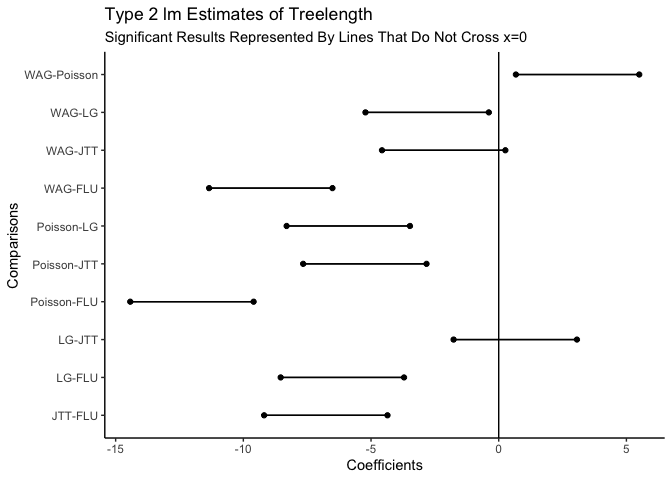

Type 2 lm Estimates of Treelength

Significant P values highlighted in red

| comparison | diff | lwr | upr | p adj |
| --- | --- | --- | --- | --- |
| JTT-FLU | -6.770619 | -9.1858280 | -4.3554098 | 0.000 |
| LG-FLU | -6.122764 | -8.5379729 | -3.7075548 | 0.000 |
| Poisson-FLU | -12.013061 | -14.4282701 | -9.5978520 | 0.000 |
| WAG-FLU | -8.925527 | -11.3407361 | -6.5103180 | 0.000 |
| LG-JTT | 0.647855 | -1.7673540 | 3.0630641 | 0.949 |
| Poisson-JTT | -5.242442 | -7.6576512 | -2.8272331 | 0.000 |
| WAG-JTT | -2.154908 | -4.5701172 | 0.2603009 | 0.106 |
| Poisson-LG | -5.890297 | -8.3055062 | -3.4750881 | 0.000 |
| WAG-LG | -2.802763 | -5.2179723 | -0.3875541 | 0.013 |
| WAG-Poisson | 3.087534 | 0.6723249 | 5.5027430 | 0.004 |

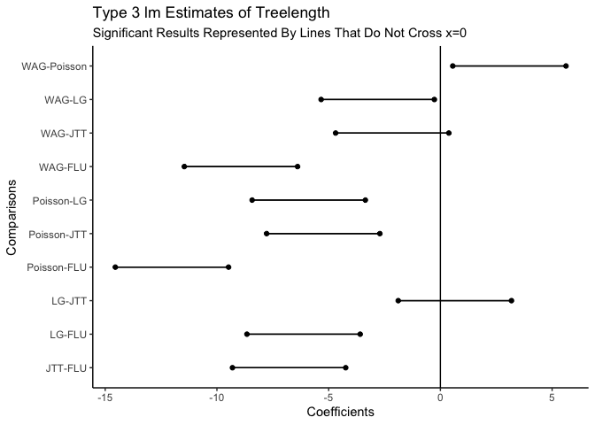

Type 3 lm Estimates of Treelength

Significant P values highlighted in red

| comparison | diff | lwr | upr | p adj |
| --- | --- | --- | --- | --- |
| JTT-FLU | -6.770619 | -9.3044773 | -4.2367605 | 0.000 |
| LG-FLU | -6.122764 | -8.6566223 | -3.5889055 | 0.000 |
| Poisson-FLU | -12.013061 | -14.5469194 | -9.4792026 | 0.000 |
| WAG-FLU | -8.925527 | -11.4593855 | -6.3916687 | 0.000 |
| LG-JTT | 0.647855 | -1.8860034 | 3.1817134 | 0.957 |
| Poisson-JTT | -5.242442 | -7.7763005 | -2.7085837 | 0.000 |
| WAG-JTT | -2.154908 | -4.6887666 | 0.3789502 | 0.138 |
| Poisson-LG | -5.890297 | -8.4241555 | -3.3564387 | 0.000 |
| WAG-LG | -2.802763 | -5.3366216 | -0.2689048 | 0.022 |
| WAG-Poisson | 3.087534 | 0.5536755 | 5.6213923 | 0.008 |

## Max Branch Length

Finally, we will look at max branch length as our summary statistic of interest.

### Summarized_bl max_bl

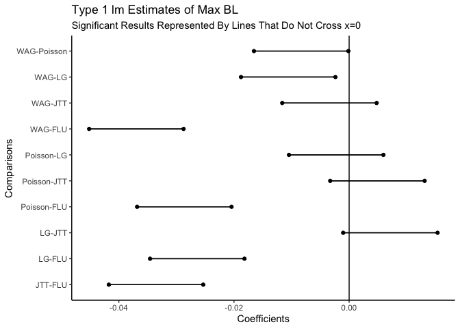

Type 1 lm Estimates of Max BL

Significant P values highlighted in red

| comparison | diff | lwr | upr | p adj |
| --- | --- | --- | --- | --- |
| JTT-FLU | -0.033541219 | -0.041740127 | -0.0253423117 | 0.000 |
| LG-FLU | -0.026378044 | -0.034576951 | -0.0181791364 | 0.000 |
| Poisson-FLU | -0.028628728 | -0.036827636 | -0.0204298205 | 0.000 |
| WAG-FLU | -0.036959775 | -0.045158682 | -0.0287608671 | 0.000 |
| LG-JTT | 0.007163175 | -0.001035732 | 0.0153620828 | 0.120 |
| Poisson-JTT | 0.004912491 | -0.003286416 | 0.0131113988 | 0.475 |
| WAG-JTT | -0.003418555 | -0.011617463 | 0.0047803521 | 0.787 |
| Poisson-LG | -0.002250684 | -0.010449592 | 0.0059482235 | 0.945 |
| WAG-LG | -0.010581731 | -0.018780638 | -0.0023828232 | 0.004 |
| WAG-Poisson | -0.008331047 | -0.016529954 | -0.0001321391 | 0.044 |

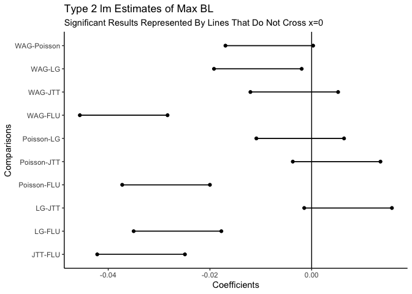

Type 2 lm Estimates of Max BL

Significant P values highlighted in red

| comparison | diff | lwr | upr | p adj |
| --- | --- | --- | --- | --- |
| JTT-FLU | -0.033541219 | -0.042162553 | -0.024919886 | 0.000 |
| LG-FLU | -0.026378044 | -0.034999378 | -0.017756710 | 0.000 |
| Poisson-FLU | -0.028628728 | -0.037250062 | -0.020007394 | 0.000 |
| WAG-FLU | -0.036959775 | -0.045581108 | -0.028338441 | 0.000 |
| LG-JTT | 0.007163175 | -0.001458158 | 0.015784509 | 0.156 |
| Poisson-JTT | 0.004912491 | -0.003708842 | 0.013533825 | 0.527 |
| WAG-JTT | -0.003418555 | -0.012039889 | 0.005202778 | 0.816 |
| Poisson-LG | -0.002250684 | -0.010872018 | 0.006370650 | 0.954 |
| WAG-LG | -0.010581731 | -0.019203064 | -0.001960397 | 0.007 |
| WAG-Poisson | -0.008331047 | -0.016952380 | 0.000290287 | 0.064 |

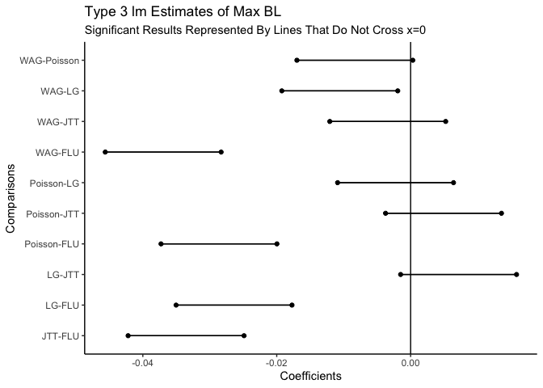

Type 3 lm Estimates of Max BL

Significant P values highlighted in red

| comparison | diff | lwr | upr | p adj |
| --- | --- | --- | --- | --- |
| JTT-FLU | -0.033541219 | -0.042197668 | -0.0248847700 | 0.000 |
| LG-FLU | -0.026378044 | -0.035034493 | -0.0177215947 | 0.000 |
| Poisson-FLU | -0.028628728 | -0.037285177 | -0.0199722788 | 0.000 |
| WAG-FLU | -0.036959775 | -0.045616224 | -0.0283033255 | 0.000 |
| LG-JTT | 0.007163175 | -0.001493274 | 0.0158196245 | 0.159 |
| Poisson-JTT | 0.004912491 | -0.003743958 | 0.0135689404 | 0.531 |
| WAG-JTT | -0.003418555 | -0.012075005 | 0.0052378938 | 0.818 |
| Poisson-LG | -0.002250684 | -0.010907133 | 0.0064057651 | 0.954 |
| WAG-LG | -0.010581731 | -0.019238180 | -0.0019252815 | 0.008 |
| WAG-Poisson | -0.008331047 | -0.016987496 | 0.0003254025 | 0.066 |

### Birds_bl max_bl

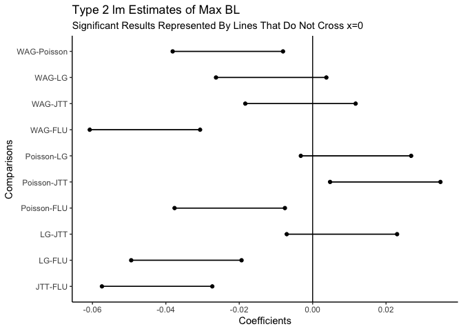

Type 2 lm Estimates of Max BL

Significant P values highlighted in red

| comparison | diff | lwr | upr | p adj |
| --- | --- | --- | --- | --- |
| JTT-FLU | -0.042383000 | -0.057418676 | -0.027347324 | 0.000 |
| LG-FLU | -0.034408289 | -0.049443965 | -0.019372613 | 0.000 |
| Poisson-FLU | -0.022595333 | -0.037631009 | -0.007559657 | 0.000 |
| WAG-FLU | -0.045704472 | -0.060740149 | -0.030668796 | 0.000 |
| LG-JTT | 0.007974711 | -0.007060965 | 0.023010387 | 0.597 |
| Poisson-JTT | 0.019787667 | 0.004751991 | 0.034823343 | 0.003 |
| WAG-JTT | -0.003321472 | -0.018357149 | 0.011714204 | 0.975 |
| Poisson-LG | 0.011812956 | -0.003222720 | 0.026848632 | 0.202 |
| WAG-LG | -0.011296183 | -0.026331859 | 0.003739493 | 0.243 |
| WAG-Poisson | -0.023109140 | -0.038144816 | -0.008073463 | 0.000 |

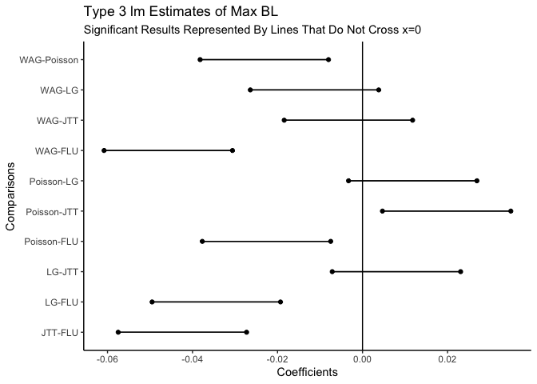

Type 3 lm Estimates of Max BL

Significant P values highlighted in red

| comparison | diff | lwr | upr | p adj |
| --- | --- | --- | --- | --- |
| JTT-FLU | -0.042383000 | -0.057486940 | -0.027279060 | 0.000 |
| LG-FLU | -0.034408289 | -0.049512229 | -0.019304349 | 0.000 |
| Poisson-FLU | -0.022595333 | -0.037699273 | -0.007491393 | 0.000 |
| WAG-FLU | -0.045704472 | -0.060808412 | -0.030600533 | 0.000 |
| LG-JTT | 0.007974711 | -0.007129229 | 0.023078651 | 0.602 |
| Poisson-JTT | 0.019787667 | 0.004683727 | 0.034891607 | 0.003 |
| WAG-JTT | -0.003321472 | -0.018425412 | 0.011782467 | 0.975 |
| Poisson-LG | 0.011812956 | -0.003290984 | 0.026916896 | 0.206 |
| WAG-LG | -0.011296183 | -0.026400123 | 0.003807757 | 0.247 |
| WAG-Poisson | -0.023109140 | -0.038213079 | -0.008005200 | 0.000 |

### Mammals_bl max_bl

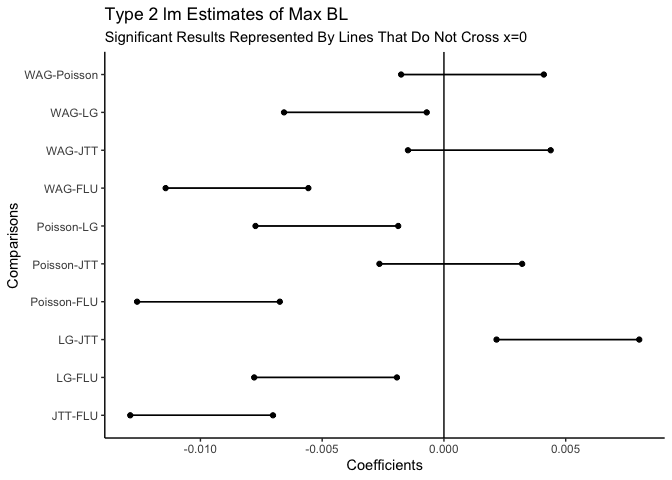

Type 2 lm Estimates of Max BL

Significant P values highlighted in red

| comparison | diff | lwr | upr | p adj |
| --- | --- | --- | --- | --- |
| JTT-FLU | -0.009951378 | -0.012881727 | -0.0070210299 | 0.000 |
| LG-FLU | -0.004861599 | -0.007791948 | -0.0019312509 | 0.000 |
| Poisson-FLU | -0.009670478 | -0.012600827 | -0.0067401299 | 0.000 |
| WAG-FLU | -0.008498366 | -0.011428714 | -0.0055680174 | 0.000 |
| LG-JTT | 0.005089779 | 0.002159431 | 0.0080201274 | 0.000 |
| Poisson-JTT | 0.000280900 | -0.002649448 | 0.0032112483 | 0.999 |
| WAG-JTT | 0.001453012 | -0.001477336 | 0.0043833609 | 0.658 |
| Poisson-LG | -0.004808879 | -0.007739227 | -0.0018785306 | 0.000 |
| WAG-LG | -0.003636766 | -0.006567115 | -0.0007064181 | 0.006 |
| WAG-Poisson | 0.001172113 | -0.001758236 | 0.0041024609 | 0.811 |

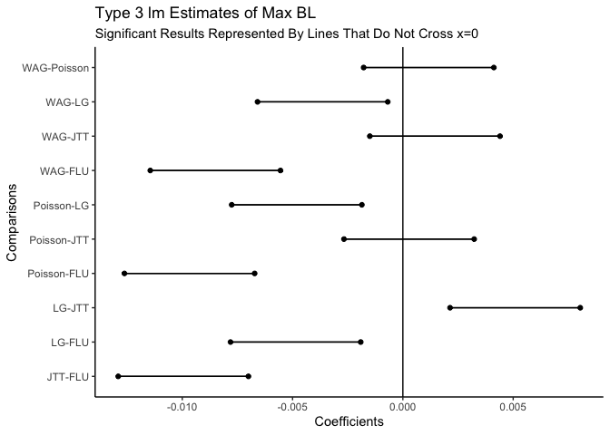

Type 3 lm Estimates of Max BL

Significant P values highlighted in red

| comparison | diff | lwr | upr | p adj |
| --- | --- | --- | --- | --- |
| JTT-FLU | -0.009951378 | -0.012902353 | -0.0070004032 | 0.000 |
| LG-FLU | -0.004861599 | -0.007812574 | -0.0019106242 | 0.000 |
| Poisson-FLU | -0.009670478 | -0.012621453 | -0.0067195033 | 0.000 |
| WAG-FLU | -0.008498366 | -0.011449341 | -0.0055473907 | 0.000 |
| LG-JTT | 0.005089779 | 0.002138804 | 0.0080407540 | 0.000 |
| Poisson-JTT | 0.000280900 | -0.002670075 | 0.0032318750 | 0.999 |
| WAG-JTT | 0.001453012 | -0.001497963 | 0.0044039875 | 0.664 |
| Poisson-LG | -0.004808879 | -0.007759854 | -0.0018579040 | 0.000 |
| WAG-LG | -0.003636766 | -0.006587742 | -0.0006857915 | 0.007 |
| WAG-Poisson | 0.001172113 | -0.001778863 | 0.0041230876 | 0.815 |

### Enzymes_bl max_bl

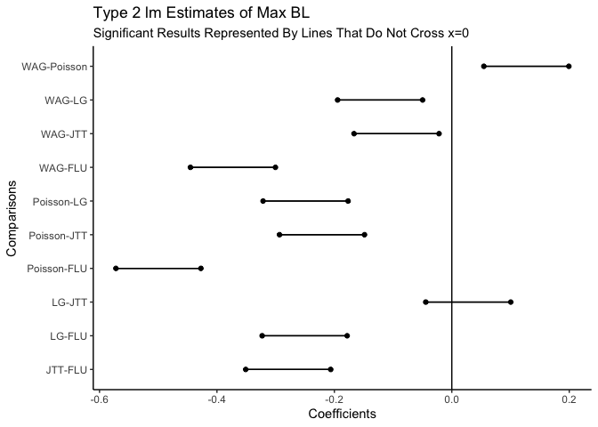

Type 2 lm Estimates of Max BL

Significant P values highlighted in red

| comparison | diff | lwr | upr | p adj |
| --- | --- | --- | --- | --- |
| JTT-FLU | -0.27862901 | -0.35100726 | -0.20625075 | 0.000 |
| LG-FLU | -0.25064186 | -0.32302011 | -0.17826360 | 0.000 |
| Poisson-FLU | -0.49971891 | -0.57209717 | -0.42734066 | 0.000 |
| WAG-FLU | -0.37278064 | -0.44515890 | -0.30040239 | 0.000 |
| LG-JTT | 0.02798715 | -0.04439111 | 0.10036541 | 0.829 |
| Poisson-JTT | -0.22108991 | -0.29346816 | -0.14871165 | 0.000 |
| WAG-JTT | -0.09415164 | -0.16652989 | -0.02177338 | 0.004 |
| Poisson-LG | -0.24907706 | -0.32145531 | -0.17669880 | 0.000 |
| WAG-LG | -0.12213879 | -0.19451704 | -0.04976053 | 0.000 |
| WAG-Poisson | 0.12693827 | 0.05456001 | 0.19931652 | 0.000 |

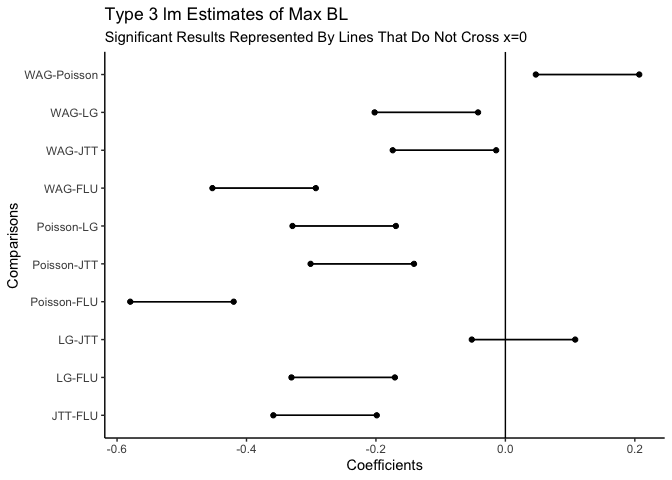

Type 3 lm Estimates of Max BL

Significant P values highlighted in red

| comparison | diff | lwr | upr | p adj |
| --- | --- | --- | --- | --- |
| JTT-FLU | -0.27862901 | -0.35852317 | -0.19873484 | 0.000 |
| LG-FLU | -0.25064186 | -0.33053602 | -0.17074770 | 0.000 |
| Poisson-FLU | -0.49971891 | -0.57961307 | -0.41982475 | 0.000 |
| WAG-FLU | -0.37278064 | -0.45267480 | -0.29288648 | 0.000 |
| LG-JTT | 0.02798715 | -0.05190701 | 0.10788131 | 0.875 |
| Poisson-JTT | -0.22108991 | -0.30098407 | -0.14119575 | 0.000 |
| WAG-JTT | -0.09415164 | -0.17404580 | -0.01425748 | 0.011 |
| Poisson-LG | -0.24907706 | -0.32897122 | -0.16918290 | 0.000 |
| WAG-LG | -0.12213879 | -0.20203295 | -0.04224463 | 0.000 |
| WAG-Poisson | 0.12693827 | 0.04704411 | 0.20683243 | 0.000 |

## What Did We Learn from all of that modeling?

-Before we begin to analyze any of the linear models constructed above, it is vital to understand that these results were obtained from small *slices* of the full datasets.

-Many of the significant findings occur when comparing Poisson to FLU, which is not surprising when considering our earlier results seen in the violin plots.

-When focusing on model type, most of the significant findings occur when performing type 1 models, which have the most predictor variables of any model type (`model`, `dataset`, and `ASRV_modified` are all predictors).

-When considering datasets, most of the significant findings occur within the enzymes dataset, which we know is the highest-divergence dataset of the three. This suggests that higher-divergence sequences lead to more exaggerated differences in the models’ estimates of branch length summary statistics.